# Probability

Notes from Edx course of Georgia Tech University

2025-10-23

# 1. Pre-requisites

## 1.1 Bootcamp: Set

**Set** is a collection of objects. Members of set are called elements.

Notation:

For sets, $A,B,C,.....$

For elements, $a,b,c,....$

For membership, $\in$ e.g. $a\in A$

For non membership, $\notin$.

For universal set, $\mathbb U$ i.e. everything.

For null set, $\phi$.

Example:

$B = \{x/0 \le x \le 1\}$ where / means such that.

$C=\{x/x \in \mathbf{R}, x^2=-1\}$ $=\phi$

Definition: If every element of $A$ is an element of $B$ then $A$ is subset of $B$. i.e. $A \subset B$.

Definition: $A=B$ iff (if and only if) $A \subset B$ and $B \subset A$.

Properties:

- $\phi \subset A$ ; $A \subset U$; $A \subset A$
- $A \subset B$, $B \subset C$ $\implies$ $A \subset C$

**Remark:** The order in which the elements of set are listed is immaterial. E.g. $\{a,b,c\}$ = $\{b,c,a\}$.

Definition: The complement of $A$ with respect to $U$ is $A^\mathbf{c} = \{x \mid x \in U \text{ and } x \notin A \}$.

Definition: The intersection of $A$ and $B$ is $A \cap B = \{x \mid x \in B \text{ and } x \in B\}$.

Definition: The union of $A$ and $B$ is $AUB = \{x \mid x \in A \text{ or } x \in B \}$.

If $A\cap B = \phi$, then $A$ and $B$ are **disjoint** or **mutually exclusive**.

Definition:

- Minus: $A-B = A \cap B^\mathbf{c}$
- Symmetric difference or XOR: $A\triangle B = (A-B) \cup (B-A) = (A \cup B) - (A \cap B)$
- The **cardinality** of $A$, denoted by $|A|$ is the number of elements in $A$. $A$ is finite if $|A| < \infty$.

  $B = \{1,2,3,....\}$ is **countably infinite** i.e. $|B| = \aleph_0$

  $C = \{x|x \in [0,1]\}$ is **uncountably infinite** i.e. $|C| = \aleph_1$

Laws of Operation:

- **Complement Law**: $A \cup A^\mathbf{c} = U$, $A \cap A^\mathbf{c} = \phi$, $(A^\mathbf{c})^\mathbf{c} = A$
- **Commutative Law**: $A \cup B = B \cup A$ , $A \cap B = B \cap A$
- **Associative Law**: $A \cup (B \cup C) = (A \cup B) \cup C$, $A \cap (B \cap C) = (A \cap B) \cap C$
- **Distributive Law**: $A \cup (B \cap C) = (A \cup B) \cap (A \cup C)$, $A \cap (B \cup C) = (A \cap B) \cup (A \cap C)$
- **De-Morgan’s Law**: $(A \cup B)^\mathbf{c} = A^\mathbf{c} \cap B^\mathbf{c}$, $(A \cap B)^\mathbf{c} = A^\mathbf{c} \cup B^\mathbf{c}$

## 1.2 Bootcamp: Derivative

Definition: The function $f(x)$ maps values of $X$ from a certain domain $X$ to a certain range $Y$ which can be denoted $f: x \xrightarrow\ Y$.

If $f(x) = x^2$ then the function takes x-values from the real line $\mathbb{R}$ to the non-negative portion of real line $\mathbb{R}^+$.

Definition: We say that $f(x)$ is **continuous** function if for any $x_0$ & $x \in X$, we have $lim_{x \to 0} f(x) = f(x_0)$ where $f(x)$ is assumed to exist for all $x \in X$.

The function $f(x) = 3x^2$ is continuous for all $x$. The function $f(x) = \lfloor x \rfloor$ i.e. round down to nearest integer e.g. $\lfloor 3.4\rfloor = 3$. This function has discontinuity at any integer $x$.

Definition: The **inverse** of function $f:X \xrightarrow\ Y$ is reverse mapping of $g: \xrightarrow\ X$ such that $f(x) = y \text{ iff } g(y) = x$ for all appropriate $x$ and $y$. The inverse is often written as $f^{-1}$ and is especially useful if $f(x)$ strictly increasing or decreasing function. Note that $f^{-1}(f(x)) = x$.

Defintion: If $f(x)$ is continuous, then it is **differentiable** if,

$$\frac{d}{dx}f(x) = f'(x) = \lim_{h \to 0} \frac{f(x+h)-f(x)}{h}$$

exists and is well defined for given $x$. The derivative of $f(x)$ is slope of the function.

$$[x^k]' = kx^{k-1}$$

$$[e^x]'=e^x$$

$$[sin(x)]'=cos(x)$$

$$[cos(x)]'=-sin(x)$$

$$[ln(x)]'=\frac{1}{x}$$

$$[arctan(x)]'=\frac{1}{1+x^2}$$

Theorem: Some properties of derivatives

$$[af(x)+b]' = af'(x)$$

$$[f(x)+g(x)]'=f'(x)+g'(x)$$

$$[f(x)+g(x)]'=f'(x)g(x)+f(x)g'(x)$$

$$[\frac{f(x)}{g(x)}]' = \frac{g(x)f'(x)-f(x)g'(x)}{g^2(x)}$$

$$[f(g(x))]'=f'(g(x))g'(x)$$

**Remark:** The second derivative $f''(x) = \frac{d}{dx}f'(x)$ and is the “slope of slope”. If $f(x)$ is position, then $f'(x)$ can be regarded as “velocity” and $f''(x)$ as “acceleration”.

The minimum or maximum of $f(x)$ can only occur when slope of $f(x)$ is 0, i.e. only when $f'(x)=0$, say at the critical point $x = x_0$. Exception: Check the endpoints of your intervals of interest as well.

If $f''(x) < 0$, you get maximum, if $f''(x)>0$, you get a minimum. If $f''(x) = 0$, you get a **point of inflection**.

## 1.3 Bootcamp: Integration

Definition: The function $F(x)$ having derivative $f(x)$ is called the **anti-derivative** or **indefinite integral**. It is denoted by $F(x) = \int f(x)dx$.

Fundamental Theorem of Calculus:If $f(x)$ is continuous, then the area under the curve for $x \in [a,b]$ is denoted and given by the **definite integral**.

$$\int_a ^b f(x)dx = F(x)|_a^b =F(b)-F(a)$$

$$\int x^kdx = \frac{x^{k+1}}{k+1}+c \;\;\;\;\;\;\; \text{ for } \; k \neq
1 \\ \text{ where c is arbitrary constant }$$

$$\int \frac{dx}{x} = ln|x| + c$$

$$\int e^xdx = e^x+c$$

$$\int cos(x)dx = sin(x)+c$$

$$\int \frac{1}{1+x^2}dx = arctan(x) + c$$

Theorem: Some well known properties of definite integrals

$$\int_a^a f(x)dx = 0$$

$$\int_a^b f(x)dx = - \int_b^a f(x)dx$$

$$\int_a^b f(x)dx = \int_a^c f(x)dx + \int_c^b f(x)dx$$

Theorem: Some other properties of general integrals:

$$\int[f(x)+g(x)]dx = \int f(x)dx + \int g(x) dx$$

$$\int f(x)g'(x)dx = f(x)g(x) - \int g(x)f'(x)dx \;\;\; \text{
integration by parts }$$

$$\int f(g(x))g'(x)dx = \int f(u)du \;\;\; \text{ Substitution rule
with u = g(x) }$$

Definition: Derivative of arbitrary order K can be written as $f^k(x)$ or $\frac{d^k}{dx^k} f(x)$. By convention $f^0(x) = f(x)$.

The **Taylor Series Expansion** of $f(x)$ about a point $a$ is given by

$$f(x) = \displaystyle\sum_{k=0}^{\infty} \frac{f^k(a)(x-a)^k}{k!}$$

The **Maclaurin Series** is simply Taylor expanded around $a = 0$.

Some famous **Maclaurin Series**;

$$sin(x) = \displaystyle\sum_{k=0}^{\infty} \frac{(-1)^kx^{2k+1}}{(2k+1)!}$$

$$cos(x) = \displaystyle\sum_{k=0}^{\infty} \frac{(-1)^xx^{2k}}{(2k)!}$$

$$e^x = \displaystyle\sum_{k=0}^{\infty} \frac{x^k}{k!}$$

Here are some miscellaneous sums:

$$\displaystyle\sum_{k=1}^{n}k = \frac{n(n+1)}{2}$$

$$\displaystyle\sum_{k=1}^{n}k^2=\frac{n(n+1)(2n+1}{6}$$

$$\displaystyle\sum_{k=0}^{\infty} = \frac{1}{1-p} \;\; (\text{ for } \;
-1<p<1)$$

Theorem: Occasionally, we run into trouble when taking indeterminate ratios of form $\frac{0}{0}$ or $\frac{\infty}{\infty}$. In such cases, **L’ Hospital Rule** is useful. If the limits $\lim_{x \to a}f(x)$ and $\lim_{x \to a} g(x)$ both go to $0$ or both go to $\infty$, then,

$$\lim_{x \to a} \frac{f(x)}{g(x)} = \lim_{x \to a}
\frac{f'(x)}{g'(x)}$$

Example:

$$\lim_{x \to 0} \frac{sin(x)}{x} = \lim_{x \to 0} \frac{cos(x)}{1} = 1$$

Double Integration:

Whereas single integrals get us the area under a curve, double integrals represent the volume under a three dimensional function.

The volume under $f(x,y) = 8xy$ over region $0<x<y<1$ is given by

$$\int_0^1\int_0^y f(x,y)dxdy = \int_0^1\int_0^y8xydxdy = \int_0^1 4y^3dy
= 1$$

We can swap the order of integration to get same answer.

$$\int_0^1\int_x^18xydydx = \int_0^14x(1=x^2)dx = 1$$

# 2. Introduction to Probability

## 2.1 Introduction

Mathematical models are either

- Deterministic (no uncertainty/randomness)
- Probabilistic (have some uncertainty)

Q. A couple has two kids and at least one is boy. What is the probability that both are boys?

Possibilities: GG, BG, GB, BB. Eliminate GG since we know that there’s at least one boy. Then $P(BB) = \frac{1}{3}$.

**Probability** is methodology that describes the random variation in systems. **Statistics** uses data (sample) to draw conclusion about population.

Definition: A **sample space** associated with an experiment E is the set of all possible outcome of E. It’s usually denoted by $S$ or $\Omega$.

Coin Toss: $S=\{H,T\}$

Toss a coin 2 times: $S:\{HH,HT, TH,TT\}$

Definition: An **event** is a set of possible outcomes. Thus, any subset of $S$ is event.

Toss a dice, $S=\{1,2,...\}$

If $A$ is event “odd number occurs”, $A=\{1,3,54\}$

The **empty set** $\phi$ is an event of $S$.

$S$ is an event of $S$.

If $A$ is an event, then $A^c$ is the **complementary** event.

If $A$ and $B$ are events, then $A \cup B$ and $A \cap B$ are events.

Definition: The **Probability** of a generic event $A \subset S$ is a function that adheres to following axioms:

- $0 \le P(A) \le 1$ (probabilities are always between 0 and 1)
- $P(S)=1$ (probability of some outcome is 1)
- If $A$ and $B$ are disjoint events, i.e. $A\cap B = \phi$ then, $P(A\cap B) = P(A) + P(B)$.
- Suppose $A_1$, $A_2,....$ is a sequence of disjoint events, i.e. $A_i \cap A_J = \phi$ for $i \neq j$.

$$\begin{align*}
P(S) &= P(U_{i=1}^{\infty}A_i) \\
&= \Sigma_{i=1}^{\infty}P(A_i) \\
&= \Sigma_{i=1}^{\infty} \frac{1}{2^i}
\end{align*}$$

Theorem: $P(A^c)=1-P(A)$

**Proof:**

$$\begin{align*}
1 &= P(S) \\
&= P(A \cup A^c) \\
&= P(A)+P(A^c) \;\;\;\; \therefore A\cap A^c = \phi
\end{align*}$$

Corollary: $P(\phi)=0$

**Proof:** By definition, $\phi=S^c$; so the result follows the theorem and axiom 2. **Remark:** The converse is false: $P(A)=0$ doesn’t imply $A=\phi$.

Theorem: For any two events $A$ and $B$,

$P(A \cup B) =P(A) + P(B) - P(A \cap B)$

**Proof:** Use Venn-diagram.

**Remark:** Axiom 3 is special case of this theorem with $A \cap B = \phi$.

Theorem: For any three events $A$, $B$ and $C$,
$$\begin{align*}
P(A\cup B\cup C) &= P(A)+P(B)+P(C)-P(A\cap B)-P(A\cap C)-P(B \cap
C)+P(A\cap B \cap C)
\end{align*}$$

Theorem: Here is the **Principle of inclusion-exclusion**:
$$\begin{align*}
P(A_1 \cup A_2 \cup .... \cup A_n) &= \Sigma_{i=1}^{n}P(A_i)
-\Sigma\Sigma_{i < j}P(A_i \cap A_j) +
\Sigma\Sigma\Sigma_{i<j<k}P(A_i \cap A_j \cap A_k) \\
&\qquad {} +.....+ (-1)^{n-1}P(A_1 \cap A_2 \cap .... A_n)
\end{align*}$$

**Remark:** You “include” all of the “single” events, “exclude” the double events, include the triple events etc.

Finite Sample Space:

Suppose S is finite $S = {S_1, S_2, .... S_n}$. Finite sample space often allows us to calculate the probabilities of certain events more efficiently. To illustrate, let $A \subset S$ be any event, then $P(A) = \Sigma_{S_i \in A} P(S_i)$.

You have 2 red cards, a blue and a yellow card. Pick a card at random then,

$S=\{S_1,S_2,S_3\}$ $=\{red, blue, yellow\}$

$P(S_1)=\frac{1}{2}$ $P(S_2)=\frac{1}{4}$ $P(S_3)=\frac{1}{4}$

$P(\text{red or yellow}) = \frac{1}{2} + \frac{1}{4}$

Definition: A **simple sample space (SSS)** is a finite sample space in which outcomes are equally likely.

**Remark:** In above example, $S$ is not simple sample space since $P(S_1) \neq P(S_2)$.

**Example:** Toss 2 fair coins,

$S = \{HH, HT, TH, TT\}$ is a $SSS$ (all probabilities are $\frac{1}{4}$).

Theorem: For any event A in $SSS$,

$P(A) = \frac{|A|}{|S|} =\frac{\text{no. of elements in A}}{\text{no. of elements in S}}$

### 2.1.1 Counting Techniques

Muffin (blueberry or oatmeal) or a bagel (sesame, plain, salt, garlic) but not both. You have $2+4=6$ choices in total.

$n_{AB}=3$ ways to go from city A to B (walk, car, bus) and $n_{BC}=4$ ways to go from B to C (car, bus, train, plane). Then you can go from A to C (via B) using $n_{AB}.n_{BC}=3*4=12$ ways.

Roll two dice. How many outcomes?

$(3,2) \neq (2,3)$ so, answer $=6*6 = 36$ ways.

Toss $n$ dice. Outcome = $6^n$ possibilities.

Toss $n$ coins. Outcome = $2^n$ possibilities.

### 2.1.2 Permutation

An arrangement of $n$ symbols in a **definite order** is a **permutation** of $n$ symbols.

Example: How many ways to arrange $1,2,3$ ?

Answer: 6 ways: 123, 132, 213, 312, 321, 231

- **Number of ways to arrange $1,2,....,n = n*(n-1)*(n-2)*.....*2*1 = n!$

Definition: The number of **r-tuples** we can make from $n$ different symbols (each used at most once) is called the **number of permutations of n things taken r at a time**.

$$P_{n,r}=\frac{n!}{(n-r)!}$$
Note: $0!=1$ & $P_{n,n}=n!$

**Proof:**
$$\begin{align*}
P_{n,r} &= (\text{choose first})(\text{choose
secoond})....(\text{choose} r^{th}) \\
&= n(n-1)(n-2)....(n-r+1) \\
&= \frac{n(n-1)...(n-r+1)(n-r)...2*1}{(n-r)...2*1} \\
&= \frac{n!}{(n-r)!}
\end{align*}$$

Example: How many license plates of 6 digits can be formed from numbers ${1,2,….9}? + with no repetitions: $P_{9,3}=60480$ + with repetitions: $9*....*9=9^6$ ways + containing repetitions: $9^6-60480=470961$

### 2.1.3 Combination

How may subsets of $\{1,2,3\}$ contain exactly 2 elements? (order isn’t important)

Answer: 3 subsets - $\{1,2\}, \{1,3\}, \{2,3\}$

Definition: The number of subsets with $r$ elements of a set with $n$ elements is called **number of combinations of n things taken r at a time**.

**Notation**: $C_{n,r}$ or $\binom{n}{r}$. These are also called **binomial coefficients**.

$$C_{n,r} = \frac{n!}{r!(n-r)!}$$
The difference between permutation and combination:

- Combination: $(a,b,c)=(b,a,c)$ i.e. order doesn’t concern,
- Permutation: $(a,b,c)\neq (b,a,c)$ i.e. concerned with order.

Choosing a permutation is same as first choosing a combination and putting the elements in order.

$$\begin{align*}
\frac{n!}{(n-r)!} &= \binom{n}{r}r! \\
\frac{n!}{(n-r)!r!} &= \binom{n}{r}
\end{align*}$$

Following results should be intuitive:

- $\binom{n}{r}=\binom{n}{n-r}$
- $\binom{n}{0}=\binom{n}{n} = 1$
- $\binom{n}{1}=\binom{n}{n-1}=n$

### 2.1.4 Binomial Theorem

$$(x+y)^n = \Sigma_{i=0}^{n} \binom{n}{i}x^iy^{n-i}$$

This is where **Pascal’s triangle** comes from.

**Corollary:** Surprising fact

$$\Sigma_{i=0}^{n} \binom{n}{i} = 2^n$$

**Proof:** By the binomial theorem:
$$\begin{align*}
2^n &= (1+1)^n \\
&= \Sigma_{i=0}^{n} \binom{n}{i}1^i1^{n-i}
\end{align*}$$

### 2.1.5 Problems

**Q. Select 2 cards from a dect without replacement and care about order?** Possibilities = $52*51 = 2652$ ways.

**Q. Box of 10 sox - 2 red and 8 black. Pick 2 without replacement.**

- Let $A$ be event that both are red.

  $P(A)=\frac{\text{ways to pick 2 reds}}{\text{ways to pick 2 sox}} =\frac{2*1}{10*9} =\frac{1}{45}$
- Let $B$ be event that both are black.

  $P(B)=\frac{8*9}{10*9} =\frac{28}{45}$
- Let $C$ be one of each color. Since, $A$ and $B$ are disjoint,

  $P(C) = 1-P(C^c) = 1- P(A \cup B) = 1 - \frac{1}{45} - \frac{28}{45} = \frac{16}{45}$

**Q. An NBA team has 12 players. How many ways can the coach choose the starting 5?**

$\binom{12}{5} = \frac{12!}{5!7!} = 792$

**Q. Smith is one of the players on the team. How many of 792 starting lineup include him?**

$\binom{11}{4} = \frac{11!}{4!7!} = 330$

**Q. 4 red marbles, 2 whites. Put them in random order.**

a. P(2 end marbles are W)

$S = \{\text{Possible pairs of slots that W's occupy}\}$

$|S| = \binom{6}{2} = \frac{6!}{2!(6-2)!} = 15$

Since, W’s must occupy end slots so, $|A| = \binom{2}{2} = 1$

$P(A) = \frac{|A|}{|S|} = \frac{1}{15}$

b. $P(\text{2 end marbles aren't both W}\} = 1-P(A) = \frac{14}{15}$

c. $P(\text{2 W's are side by side\}}$

WWRRRR or RWWRRR or RRWWRR or RRRWWRR or RRRRWW

$|B| = 5$

$P(B) = \frac{5}{15}$

## 2.2 Hypergeometric Distribution

Definition: You have $a$ objects of type 1 and $b$ objects of type 2. Select $n$ objects **without replacement** from $a+b$ objects. Then,

$$\begin{align*}
P(\text{k type 1's were picked}) &= \frac{(\text{Number of ways
to choose k type 1's out of a})(\text{Choose n-k type 2's out of
b})}{(\text{Number of ways to choose n out of a+b})} \\
&= \frac{\binom{a}{k} \binom{b}{n-k}}{\binom{a+b}{n}}
\end{align*}$$

The number of type 1’s chosen is said to have the **hypergeometric distribution**.

**Example**: 3 sox in box with $a=2$ red, $b=1$ blue. Pick $n=3$ without replacement.

$$\begin{align*}
P(\text{Exactly k=2 reds are picked}) &= \frac{\binom{a}{k}
\binom{b}{n-k}}{\binom{a+b}{n}} \\
&= \frac{\binom{2}{2} \binom{1}{1}}{\binom{3}{3}} \\
&= 1
\end{align*}$$

## 2.3 Binomial Distribution

Definition: You again have a objhects of type 1 and b objects of type 2. Now, select n objects **with replacement** from $a+b$ objects.

$$\begin{multline*}
P(\text{k type 1's were picked}) = (\text{Number of ways to choose k
1's and n-k 2's})\\
P(\text{Choose k 1's in a row then n-k 2's in a row})
\end{multline*}$$
$$\begin{align*}
P(\text{k type 1's were picked}) = \binom{n}{k} \binom{a}{a+b}^k
\binom{b}{a+b}^{n-k}
\end{align*}$$

## 2.4 Multinomial Coefficients

**Example:** $n_1$ blue sox, $n_2$ reds. The number of assortments is $\binom{n_1 + n_2}{n_1}$. Generalization for $k$ types of objects: $n = \Sigma_{i=1}^{k}n_i$ The number of arrangements is
$$\binom{n}{n_1, n_2,.... n_k} = \frac{n!}{n_1!n_2!....n_k!}$$
This is known as **multinomial coefficient**.

**Example:** How many ways letters in “MISSISSIPPI” be arranged?

$$\frac{\text{Number of permutations of 11 letters}}{(\text{Number of
M's})(\text{Number of P's})(\text{Number of
I's})(\text{Number of S's})}$$

$$= \frac{11!}{1!2!4!4!}$$

## 2.5 Conditional Probability

The probability of A occurs given B occurs is

$$P(A/B) = \frac{|A \cap B|}{|B|} =
\frac{\frac{|A \cap B|}{|S|}}{\frac{|B|}{|S|}} =
\frac{P(A \cap B)}{P(B)}$$

Definition: If $P(B)>0$, the conditional probability of $A$ given $B$ is

$$P(A/B) = \frac{P(A \cap B)}{P(B)}$$

**Remark:** If $A$ and $B$ are disjoint, then $P(A/B)=0$. If $B$ occurs, there is no chance that A can occur.

What happens if $P(B)=0$ ? In that case, no need to consider $P(A/B)$.

**Example:** Toss 2 dice and take the sum.

A: odd toss = $\{3,5,7,9,11\}$

B: $\{2,3\}$

$P(A) = P(3) + .... + P(11) = \frac{2}{36} + \frac{4}{36} + ... + \frac{2}{36} = \frac{1}{2}$

$P(B) = \frac{1}{36} + \frac{2}{36} = \frac{1}{12}$

$P(A/B) = \frac{P(A \cap B)}{P(B)} = \frac{\frac{2}{36}}{\frac{1}{12}} = \frac{2}{3}$

**Example:** A couple has two kids and at least one is boy. What’s the probability that both are boys?

$S = \{GG, GB, BG, BB\}$

$C: \text{Both are boys} = \{BB\}$

$D: \text{At least 1 boy} = \{GB, BG, BB\}$

$P(C/D) = \frac{P(C \cap D)}{P(D)} = \frac{P(C)}{P(D)} = \frac{\frac{1}{4}}{\frac{3}{4}} = \frac{1}{3}$

**Example:** A couple has two kids and at least one is born on tuesday. What is the probability that both are boys?

$B_x[G_x] = Boy[Girl] \\ \text{born on day x; x = 1,2,....7}$

$x=3$ is Tuesday.

$S = \{(G_x, G_y), (G_x, B_y), (B_x. G_y), (B_x, B_y), x,y = 1,2,...7\}$

So, $|S| = 4*49 = 196$

i.e. 4 combination of B and G and 49 combination of x and y.

C: Both are boys (with at least one born on tuesday)

$= \{(B_x, B_3), x = 1,2,...,7\} \cup \{(B_3, B_y), y = 1,2,....7\}$

Note: $|C| = 13 \{ \text{to avoid double counting} (B_3,B_3)\}$

D: There is at least one boy born on Tuesday.

$= C \cup \{(G_x, B_3), (B_3, G_y), x,y = 1,2,....7\}$

$|D| = 27$

$P(C/D) = \frac{P(C \cap D)}{P(D)} = \frac{P(C)}{P(D)} = \frac{\frac{13}{196}}{\frac{27}{197}} = \frac{13}{27}$

Properties: Analogous to axioms of probability

- $0 \leq P(A/B) \leq 1$
- $P(S/B) = 1$
- $A_1 \cap A_2 = \phi \rightarrow P(A_1 \cap A_2/B) = P(A_1/B) + P(A_2/B)$
- If $A_1$, $A_2,.....$ are all disjoint then

  $$P(U_{i=1}^{\infty} A_i/B =
  \Sigma_{i=1}^{\infty} P(A_i/B)$$

## 2.6 Independence

Any unrelated events are independent.

**Example:**

A: It rains on Mars tomorrow.

B: Coin lands on H.

Definition: A & B are independent iff $P(A \cap B) = P(A).P(B)$

**Remark:** If $P(A) = 0$, then $A$ is independent of any other event.

**Remark:** Events don’t have to be physically unrelated to be independent.

Theorem: Suppose $P(B) > 0$. Then $A$ and $B$ are independent $\leftrightarrow$ $P(A/B) = P(A)$.

**Proof:** A & B independent $\leftrightarrow$ $P(A \cap B) = P(A).P(B) \leftrightarrow \frac{P(A \cap B)}{P(B)} = P(A)$

**Remark:** So, if $A$ and $B$ are independent, the probability of $A$ doesn’t depend on whether or not $B$ occurs.

Bayes Theorem: $A$ and $B$ are independent $\leftrightarrow$ $A'$ and $B'$ are also independent.

**Proof:** Only need to prove in $\rightarrow$ direction (then $\leftarrow$ follows trivially).
$$P(A) = P(A \cap B') + P(A \cap B)$$
So,
$$\begin{align*}
P(A \cap B') &= P(A) - P(A \cap B) \\
&= P(A) - P(A).P(B) \;\;\;\;\; \{\text{A, B are independent}\} \\
&= P(A)\{1-P(B)\} \\
&= P(A).P(B')
\end{align*}$$

**Don’t confuse independence with disjointness!**

Theorem: If $P(A)>0$ and $P(B)>0$, $A$ and $B$ can’t be independent and disjoint at the same time.

**Proof:** Suppose $A$ and $B$ are disjoint, $A \cap B = \phi$ . Then, $P(A \cap B) = 0 < P(A).P(B)$. Thus, $A$ and $B$ aren’t independent. Similarly, independent doesn’t imply disjoint.

**Remark:** In fact, independence and disjointness are almost opposite. If $A$ and $B$ are disjoint and $A$ occurs, then you have information that $B$ cannot occur. So, $A$ and $B$ can’t be independent.

Extension to more than two events:

Definition: A, B, C are independent iff

- $P(A \cap B \cap C) = P(A).P(B).P(C)$
- All pairs are independent:

  $P(A \cap B) = P(A).P(B)$

  $P(A \cap C) = P(A).P(C)$

  $P(B \cap C) = P(B).P(C)$

General Definition: $A_1,......, A_k$ are independent iff $P(A_1 \cap..... \cap A_k) = P(A_k)$ and all subsets of $\{A_1,....,A_k\}$ are independent.

Independent Trials: Perform $n$ trials of an experiment such that the outcome of one trial is independent of outcomes of other trials. Eg. Flip 3 coins independently.

**Remark:** For independent trials, you just multiply the individual probabilities.

Eg. Flip a coin infinitely many times (each flip is independent of others).
$$\begin{align*}
P_n &= P(\text{First H on nth trial}) \\
&= P(\underbrace{TT...T}_{n-1}H) \\
&= \underbrace{P(T).P(T)...P(T)}_{n-1}.P(H) \\
&= (\frac{1}{2})^{n-1}.\frac{1}{2} = \frac{1}{2^n} \\
&= \frac{1}{2^n} \;\;\;\; \{\text{Each has probability 1/2}\} \\
P(H \; eventually) &= \Sigma_{n=1}^{\infty}P_n \\
&= \Sigma_{n=1}^{\infty}2^{-n} \\
&= 1 \\
\end{align*}$$

## 2.7 Partitions and laws of probability

**Partition of Sample Space** split the sample space into disjoint, yet all encompassing subsets.

Definition: The events $A_1, A_2,....,A_n$ form a partition of sample space $S$ if

- $A_1, A_2,....,A_n$ are disjoint.
- $U_{i=1}^{n}A_i = S$
- $P(A_i) > 0$ for all $i$.

**Remark:** When an experiment is performed, exactly one $A_i$’s occur.

**Example:** $A$ and $A'$ form partition.

Suppose $A_1, A_2,....,A_n$ form partition of $S$ and $B$ is arbitrary event. Then,

$$B = U_{i=1}^{n}(A_i \cap B)$$

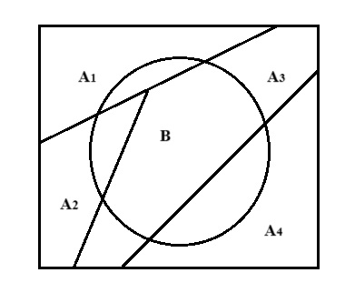

Partitions

$$\begin{align*}
P(B) &= P[U_{i=1}^{n}(A_i \cap B)] \\
&= \Sigma_{i=1}^{n}P(A_i \cap B) \;\;\; (\text{Since} A_1,
A_2,...A_n \; \text{are disjoint}) \\
&= \Sigma_{i=1}^{n}P(A_i)P(B/A_i) \;\;\; (\text{Definition of
conditional Probability})
\end{align*}$$
This is **law of probability**.

**Example:** Suppose we have 10 Georgia Tech students and 20 University of Georgia students taking a test. GT students have 95% chance of passing but UGA have 50%. Determine probability that he/she passes.

$P(passes) = P(GT)P(passes/GT)+P(UGA)P(passes/UGA)$

## 2.8 Bayes Theorem

Immediate consequence of law of total probability.

Bayes Theorem: If $A_1, A_2,...A_n$ form partition of $S$ and $B$ is any event then,
$$\begin{align*}
P(A_j/B) &= \frac{P(A_j \cap B)}{P(B)} \\
&= \frac{P(A_j)P(B/A_j)}{\Sigma_{i=1}^{n}P(B/A_i)}
\end{align*}$$

The $P(A_j)$’s are prior probabilities (“before B”).

The $P(A_j/B)$’s are posterior probabilities (“after B”).

The $P(A_j/B)$’s add up to 1.

## 2.9 Probability Problems

Birthday Problem

**Q. There are n people in room. Find the probability that at least two have the same birthday. (Ignore Feb 29 and assume that all 365 days have equal probability.**

The (simple) sample size is $S = \{(x_1,.....,x_n):x_i \in \{1,2,....365\}, V_i\}$

($x_i$ is person $i$’s birthday) and note that $|S| = (365)^n$.

Let A: All birthdays are different then,
$$\begin{align*}
P(A) &= \frac{(365)(364)....(365-n+1)}{365}^n \\
&= 1.\frac{364}{365}.\frac{363}{365}....\frac{365-n+1}{365}
\end{align*}$$
$$\begin{align*}
P(A') &= 1 - P(A)
\end{align*}$$
When, $n=366$, $P(A')=1$

For, $P(A') > \frac{1}{2}$, n must be $\ge 23$.

When, $n=50$, $P(A')=0.97$, $P(A')$ is probability of at least one birthday match (not unique).

The Envelope Problem

**Q. A group of n people receives n envelopes with their name on them but someone has completely mixed up the envelopes. Find the probability that at least one person will receive the proper envelope.**

Let $A_i$: Person i receive correct envelope.

We want $P(A_1 \cup A_2 .... \cup A_n)$

By principle of Inclusion-Exclusion,
$$\begin{align*}
P(A_1 \cup A_2 \cup .... \cup A_n) &= \Sigma_{i=1}^{n}P(A_i)
-\Sigma\Sigma_{i < j}P(A_i \cap A_j) +
\Sigma\Sigma\Sigma_{i<j<k}P(A_i \cap A_j \cap A_k) \\
&\qquad {} +.....+ (-1)^{n-1}P(A_1 \cap A_2 \cap .... A_n)
\end{align*}$$

Since all $P(A_i)$’s are same, all of $P(A_i \cap A_j)$’s are the same.
$$P(A_1 \cup A_2 \cup .... \cup A_n) \\
= nP(A_1) - \binom{n}{2}P(A_1 \cap A_2) + \binom{n}{3}P(A_1 \cap A_2
\cap A_3) +.....+ (-1)^{n-1}P(A_1 \cap A_2 ... \cap A_n)$$
$$\begin{align*}
P(A_1) &= \frac{1}{n} \\
P(A_2) &= \frac{1}{n-1} \\
P(A_1 \cap A_2) &= \frac{1}{n(n-1)} \\
P(A_1 \cup A_2 \cup .... \cup A_n) &=
\frac{n}{n}-\binom{n}{2}\frac{1}{n}.\frac{1}{n-1}+\binom{n}{3}\frac{1}{n}.\frac{1}{n-1}.\frac{1}{n-2}+....+(-1)^{n-1}\frac{1}{n!}
\\
&= 1-\frac{1}{2!}+\frac{1}{3!}+....+(-1)^{n-1}\frac{1}{n!} \\
&= 1-\frac{1}{e} \;\;\; \{\text{Very similar to Mclaurin Series}\}
\\
&= 0.6321
\end{align*}$$

If $n=4$ envelopes:
$$\begin{align*}
P(A_1 \cup A_2 \cup A_3 \cup A_4) &=
1-\frac{1}{2!}+\frac{1}{3!}-\frac{1}{4!} \\
&= 0.625
\end{align*}$$

# 3. Random Variables

## 3.1 Univariate Random Variables

Definition: A **random variable (RV)** is a function from the sample space to the real line. $X:S \rightarrow \mathbb{R}$.

Example: Flip 2 coins: $S = \{HH, HT, TH, TT\}$

Suppose $X$ is RV corresponding to the number of $H$’s,

$X(TT)=0$, $X(HT)=1$, $X(HH)=2$

$P(X=0)=\frac{1}{4}$, $P(X=1)=\frac{1}{2}$, $P(X=2)=\frac{1}{4}$

Notation: Capital letters like $X,Y,Z$ usually represent RV’s. Small letters like $x,y,z$ represent particular values of RV’s.

Example: Flip a coin
$$X =
\begin{cases}
1 & \text{if T} \\
0 & \text{if H}
\end{cases}$$
Roll a die
$$Y =
\begin{cases}
0 & \text{if \{1,2,3\}} \\
1 & \text{if \{4,5,6\}}
\end{cases}$$
For our purpose, $X$ and $Y$ are same, since $P(X=0) = p(Y=0) = \frac{1}{2}$ and $P(X=1) = P(Y=1) = \frac{1}{2}$.

**Example:** Select a real number at random between ) and 1. There are infinite number of “equally likely” outcome.

Conclusion: P(we choose the individual point x) = P(X = x) = 0.

But $P(X \leq 0.65) = 0.65$ and $P(X \in [0.3, 0.7]) = 0.4$.

If A is an interval in $[0,1]$ then $P(X \in A)$ is the length of $A$.

Definition: If a number of possible values of a RV X is finite or countably infinite then X is **discrete** RV otherwise,

A **continuous** RV is one with probability 0 at every point.

**Example:**

- Flip a coin - get H or T. Discrete
- Pick a point at random in $[0,1]$. Continuous
- The amount of time you wait in line is either 0 (with positive probability) or some positive real number - a combined discrete - continuous RV.

### 3.1.1 Discrete Random Variable

Definition: If $X$ is discrete RV, its **probability mass function (pmf)** is

$f(x) = P(X=x)$

Note that $0 \leq f(x) \leq 1$, $\sum_xf(x)=1$

**Example:** Flip 2 coins. Let X be number of heads.
$$f(x) =
\begin{cases}
\frac{1}{4} & \text{if x = 0 or 2} \\
\frac{1}{2} & \text{if x = 1} \\
0 & \text{otherwise}
\end{cases}$$

#### 3.1.1.2 Uniform Distribution:

Uniform distribution of integers $1,2,....n$. $X$ can equal $1,2,....n$ each with probability $\frac{1}{n}$.
$$f(i) = \frac{1}{n} \;\;\; i = 1,2,.....n$$

#### 3.1.1.2 Binomial Distribution:

Let $X$ denote number of “successes” from $n$ independent trials such that $P$ (success) at each trial is $p \;\; (0 \le p \le 1)$. Then $X$ has the binomial distribution with parameters $n$ and $p$. The trials are referred to as **Bernoulli Trials**.

**Notation:** $X \sim Bern(n,p)$

**Example:** Roll a die 3 independent times. Find P(Get exactly two 6’s)

“success (6)” and “failure” (1,2,3,4,5)

All trials are independent, $P(success) = \frac{1}{6}$ doesn’t change from trial to trial.

Let X = number of 6’s. Then $X \sim Bern(3, \frac{1}{6})$.

Theorem: If $X \sim Bern(n,p)$ then probability of $k$ successes in n trials is
$$P(X = k) = \binom{n}{k}p^kq^{n-k}$$
where,
$$K = 0,1,....n \;\; \text{and} \;\; q = 1-p$$

**Proof:** Consider the particular sequence of success and failures.
$$\begin{align*}
\underbrace{SS...S}_{k \; success}\;\underbrace{FF...F}_{n-k \; failure}
\\
prob = p^kq^{n-k}
\end{align*}$$
The number of ways to arrange the sequence is $\binom{n}{k}$.

**Example:** Roll 2 dice and get the sum. Repeat 12 times. Find P(Sum will be 7 or 11 exactly 3 times).

$$\begin{align*}
P(\text{7 or 11}) &= P(7) + P(11) \\
&= \frac{7}{36} + \frac{2}{36} \\
&= \frac{2}{9}
\end{align*}$$
So, $X \sim Bin(12, \frac{2}{9})$ then,
$$\begin{align*}
P(X = 3) &= \binom{12}{3}\binom{2}{9}^3\binom{7}{9}^9
\end{align*}$$

#### 3.1.1.3 Poisson Distribution:

If $P(X=k) = \frac{e^{-\lambda} \lambda^k}{k!} \;\;,k=0,1,2,...\lambda, \; \lambda>0$, we say that X has the **Poisson distribution** with parameter $\lambda$.

**Notation:** $X \sim Pois(\lambda)$

**Example:** Suppose the number of raisins in a cup of cookie dough is Pois(10). Find the probability that cup of dough has at least 4 raisins.
$$\begin{align*}
P(X \ge 4) &= 1 - P(X = 0,1,2,3) \\
&= 1-
e^{-10}(\frac{10^0}{0!}+\frac{10^1}{1!}+\frac{10^2}{2!}+\frac{10^3}{3!})
\\
&= 0.9897
\end{align*}$$

### 3.1.2 Continuous Random Variables

**Example:**Pick a point X randomly between 0 and 1 and define the continuous function.

$$f(x) =
\begin{cases}
1 & \text{if } 0 \leq x \leq 1 \\
0 \text{otherwise }
\end{cases}$$
Intuitively, if $0 \leq a \leq b \leq 1$ then,

$$\begin{align*}
P(a \leq X \leq b) &= \text{the "area" under f(x) from a
to b} \\
&= b - q
\end{align*}$$

Definition: Suppose X is a continuous RV, the magic function f(x) is **probability density function (PDF)** if

- $\int_{\mathbb{R}} f(x)dx=1$ (area under the f(x) is 1)
- $f(x) \geq 0$
- If $A \subseteq \mathbb{R}$, then $P(X \in A)= \int_Af(x)dx$ (probability that X is in a certain region of A)

**Remark:** If X is continuous RV then,
$$P(a < X < b) = \int_a^bf(x)dx$$
An individual point has probability 0 i.e. $P(x = x) = 0$.

If X is discrete then $f(x) = P(X=x)$ and must have $0 \leq f(x) \leq 1$.

If X is continuous,

- $f(x)$ is continuous,
- Instead think of $f(x)dx \approx P(x < X < x+dx)$.
- Must have $f(x) \geq 0$ and possibly $>1$.

#### 3.1.2.1 Uniform Distribution

If X is “equally likely” o be anywhere between a and b then $X$ has the uniform distribution on $(a,b)$.

$$f(x) =
\begin{cases}
\frac{1}{b-a} \text{ if } a<x<b \\
0 \text{ otherwise }
\end{cases}$$
**Notation:** $X \sim Unif(a,b)$

**Remark:** $\int_{\mathbb{R}}f(x)dx = \int_a^b\frac{1}{b-a}dx=1$

**Example:** If $X \sim Unif(-2,8)$ then,
$$P(-1 < X < 6) = \int_{-1}^6 \frac{1}{8-(-2)} dx = 0.7$$

#### 3.1.2.2 Exponential Distribution

X has the exponential distribution with parameter $\lambda > 0$ if it has PDF $f(x) = \lambda e^{-\lambda x}, \text{ for } x \geq 0$.

**Notation:** $X \sim Exp(\lambda)$

**Remark:** $\int_{\mathbb{R}}f(x)dx = \int_0^\infty \lambda e^{-\lambda x}dx = 1$

**Example:** Suppose X is a continuous RV with PDF

$$f(x) =
\begin{cases}
cx^2 \text{ if } 0 < x < 2 \\
0 \text{ otherwise }
\end{cases}$$
First of all, let’s find c. Noting that PDF must integrate to 1 we have,

$$\begin{align*}
1 &= \int_{\mathbb{R}}f(x)dx \\
1 &=\int_0^2cx^2dx \\
1 &=\frac{cx^3}{3} \Big|_0^2 \\
1 &= \frac{8c}{3} \\
c &= \frac{3}{8} \\
\text{this means } \\
f(x) &= \frac{3x^2}{8}
\end{align*}$$
$$\begin{align*}
P(0 < X < 1 \mid \frac{1}{2} < X < \frac{3}{2}) &=
\frac{P(0 < X < 1 \cap \frac{1}{2} < X <
\frac{3}{2})}{P(\frac{1}{2} < X < \frac{3}{2})} \\
&= \frac{P(\frac{1}{2} < X < 1)}{P(\frac{1}{2} < X <
\frac{3}{2})} \\
&= \frac{\int_{\frac{1}{2}}^1 \frac{3}{8} x^2
\,dx}{\int_{\frac{1}{2}}^{\frac{3}{2}} \frac{3}{8} x^2 \,dx} \\
&= \frac{7}{26}
\end{align*}$$

X has the **standard normal distribution** if its PDF is
$$\phi(x) = \frac{1}{\sqrt{2\pi}}e^{-\frac{x^2}{2}} \;\; \text{for all } x
\in \mathbb{R}$$

### 3.1.3 Cumulative Probability Distribution

Definition: For any RV (discrete or continuous), the cumulative distribution function (cdf) is defined for all x by,

$$F(x) = P(X \le x)$$
For X discrete,
$$F(x) = \Sigma_{\{y/y \le x\}}f(y) = \Sigma_{\{y/y \le x\}}P(X = y)$$
For X condinuous,
$$F(x) = \int_{-\infty}^xf(y)dy$$
**Example:** Flip a coin twice. let X = number of H’s.
$$X =
\begin{cases}
0 \text{ or } 2 \text{ with prob } \frac{1}{4} \\
1 \text{ with prob } \frac{1}{2}
\end{cases}$$
The CDF is a step function
$$F(x) = P(X \le x) =
\begin{cases}
0 \text{ if } x < 0 \\
\frac{1}{4} \text{ if } 0 \le x < 1 \\
\frac{3}{4} \text{ if } 1 \le x < 2 \\
1 \text{ if } x \ge 2
\end{cases}$$

Explanation

X defined as number of heads from two independent flips of a fair coin. $X=0$ (no heads), $X=1$ (one head) and $X=2$ (two heads). The probability distribution of X follows binomial distribution i.e. $X \sim Binom(2, \frac{1}{2})$.
$$P(X = 0) = \binom{2}{0} \big(\frac{1}{2}\big)^0\big(\frac{1}{2}\big)^2 =
\frac{1}{4}$$
$$P(X = 1) = \binom{2}{0} \big(\frac{1}{2}\big)^1\big(\frac{1}{2}\big)^1 =
\frac{1}{2}$$
$$P(X = 2) = \binom{2}{0} \big(\frac{1}{2}\big)^2\big(\frac{1}{2}\big)^0 =
\frac{1}{4} \\$$
For $x<0$, $F(x)=0$.

For $0 \le x < 1$, $F(x)=P(X=0)=\frac{1}{4}$.

For $1 \le x < 2$, $F(x)=P(X=0)+P(X=1)=\frac{1}{4}+\frac{1}{2}=\frac{3}{4}$

For $x \ge 2$, $F(x)=P(X=0)+P(X=1)+P(X=2)=\frac{1}{4}+\frac{1}{2}+\frac{1}{4} = 1$

Warning: For discrete RVs, be careful about $\le$ vs $<$ as the endpoints of the range (where step function jumps).

Theorem (Continuous CDF): If X is continuous RV, then $f(x)=F'(x)$ (assuming the derivative exists.)

**Proof:**
$$F'(x) = \frac{d}{dx} \int_{-\infty}^{x}f(t)dt = f(x), \;\;\; \text{
by the fundamental theorem of calculus }$$

**Example:** $X \sim Unif(0,1)$. The PDF and cdf are
$$f(x) =
\begin{cases}
1 \text{ if } 0<x<1 \\
0 \text{ otherwise }
\end{cases}$$
$$F(x) =
\begin{cases}
0 \text{ if } x \le 0 \\
x \text{ if } 0<x<1 \\
1 \text{ if } x \ge 1
\end{cases}$$

Explanation

$$f(x) = \frac{1}{1-0} = 1 \;\; \text{ for } 0<x<1$$

So,

$$F(x) = P(X \le x) = \int_{-\infty}^{x}f(t)dt$$

For $x \le 0$, $F(x)=0$ since all values are between 0 and 1.

For $0<x<1$, $F(x)=\int_{-\infty}^{x}1dt = x$.

For $x \ge 1$, $F(x)=1$ since $x \ge 1$ includes all the probability.

**Example:** $X \sim Exp(\lambda)$

$$f(x) =
\begin{cases}
\lambda e^{-\lambda x} \text{ if } x > 0 \\
0 \text{ otherwise}
\end{cases}$$

$$F(x) = \int_{-\infty}^{x}f(t)dt =
\begin{cases}
0 \text{ if } x\le 0 \\
1-e^{-\lambda x} \text{ if } x > 0
\end{cases}$$

We can use CDF to find **median** of X that is the point m such that,

$$0.5 = F(m) = 1-e^{-\lambda m} \\
m = \big(\frac{1}{\lambda}\big) ln(2)$$

Explanation

For, $x\le 0, f(x) = 0$. So, $F(x)=0$.

For, $x>0$, $F(x)=\int_0^x \lambda e^{-\lambda x}dx =1-e^{-\lambda x}$

**Properties of CDF**

$F(x)$ is non-decreasing in x i.e. $a<b$ implies $F(a) \le F(b)$.

$$\lim_{x \rightarrow \infty} F(x) = 1 \\
\lim_{x \rightarrow -\infty} F(x)=0$$

$F(x)$ is right continuous at every point x.

Theorem: $P(X>x) = 1- F(x)$

**Proof:**

By complements,

$$P(X>x) = 1 - P(X \le x) = 1 - F(x)$$

Theorem: $a<b \implies P(a < X \le b) = F(b) - F(a)$.

**Proof:** Since $a<b$, we have,

$$\begin{align*}
P(a < X \leq b) &= P(X > a, X \leq b) \\
&= P(X > a) + P(X \leq b) - P(X > a \cup X \leq b) \\
&= 1 - F(a) + F(b) - 1 \\
&= F(b) - F(a)
\end{align*}$$

where,
$$P(X>a) = 1- F(a) \\
P(X \le b) = F(b) \\
P(X>a \cup X \le b) = 1$$

### 3.1.4 Great Expectations

Definition: The **mean** or **expected value** or **average** of random variable X is
$$\mu = E(x) =
\begin{cases}
\Sigma_x xf(x) \text{ if X is discrete} \\
\int_{\mathbb{R}}xf(x)dx \text{ if X is continuous}
\end{cases}$$
The mean gives an indication of RV’s central tendency. Think of it as a weighted average of the possible x’s where the weights are given by f(x).

**Example:** Suppose X has the Bernoulli distribution with parameter p i.e. ($P(X=1)=p$ and $P(X=0)=q=1-p$). Then,

$$E(x) = \Sigma_x xf(x) = 1.p+0.q = p$$

**Example:** Die toss. $X=1,2,...6$ each with probability $\frac{1}{6}$. Then,

$$E(x)= \Sigma_x xf(x) =1. \frac{1}{6} + .....+6. \frac{1}{6} = 3.5$$

Suppose X has the **geometric distribution** with the parameter p i.e. x is the number of Bern(p) trials until you obtain your first success (e.g. $FFFS$ gives x = 4).

$$f(x) = (1-p)^{x-1}p, \;\; x = 1,2,...$$

**Notation:** $X \sim Geom(p)$

Suppose I take independent foul shots but the chanse of making any particular shot is only 0.4. What’s the probability that it will take me at least 3 tries to make succeessful shot?

The number of tries until my first success is $X \sim Geom(0.4)$. Thus,

$$\begin{align*}
P(X \ge 3) &= 1 - P(X \le 2) \\
&= 1 - P(X=1) - P(X=2) \\
&= 1 - 0.4 - 0.6*0.4 \\
&= 0.36
\end{align*}$$

Now, lets find the **expected value** of $X \sim Geom(p)$

$$\begin{align*}
E(X) &= \Sigma_x xf(x) \\
&= \Sigma_{x=1}^\infty xq^{x-1}p \;\; (\text{where } q=1-p) \\
&= p \Sigma_{x=1}^\infty \frac{d}{dq} q^x \\
&= p \frac{d}{dq} \Sigma_{x=1}^\infty q^x \;\; (\text{swap
derivative and sum}) \\
&= p \frac{d}{dq} \frac{q}{1-q} \;\; (\text{geometric sum}) \\
&= p\{\frac{(1-q)-q(-1)}{(1-q)^2}\} \\
&= \frac{1}{p}
\end{align*}$$

**Example:** $X \sim Exp(\lambda)$. $f(x)=\lambda e^{-\lambda x}, x\ge 0$. Then,

$$\begin{align*}
E(X) &= \int_{\mathbb{R}} xf(x)dx \\
&= \int_0^\infty x \lambda e^{-\lambda x}dx \\
&= -xe^{-\lambda x} \big|_0^\infty - \int_0^\infty (-e^{-\lambda
x}dx \;\; (\text{by parts}) \\
&= \int_0^\infty e^{-\lambda x} dx \;\; (\text{L' Hôspital
rule})\\
&= \frac{1}{\lambda}
\end{align*}$$

### 3.1.4 Law of the unconscious statistician (LOTUS)

Theorem: The expected value of a function of X, say $h(x)$ is,
$$E[h(X)] =
\begin{cases}
\sum_x h(x)f(x) & \text{if } X \text{ is discrete}, \\
\int_{\mathbb{R}} h(x)f(x) \, dx & \text{if } X \text{ is
continuous.}
\end{cases}$$
$E[h(x)]$ is weighted function of $h(x)$ where the weights are $f(x)$’s.

**Remark:** It looks like a definition, but it’s really a theorem - that’s why they call it LOTUS.

**Example:** $E[sinx] = \int_{\mathbb{R}} sinx f(x)dx$

Definition: The $k^{th}$ moment is
$$E[X^k] =
\begin{cases}
\sum_x x^k f(x) & \text{if X is discrete} \\
\int_{\mathbb{R}} x^k f(x)dx & \text{if X is continuous}
\end{cases}$$
**Example:** Suppose $X \sim Bern(p)$ so that $f(1) = p$ and $f(0)=q$.
$$E[X^k] = \sum_x x^k f(x) = 0^kq+1^kp = p \; \;\;\text{ for all } k!$$
**Example:** Suppose $X \sim Exp(\lambda)$. $f(x) = \lambda e^{-\lambda x}, x \ge 0$ then,

$$\begin{align*}
E[X^k] &= \int_{\mathbb{R}} x^k f(x)dx \\
&= \int_0^\infty x^k \lambda e^{-\lambda x}dx \\
&= \int_0^\infty \Big(\frac{y}{\lambda}\Big)^k \lambda e^{-\lambda
\frac{y}{\lambda}}
\frac{1}{\lambda} dy \;\;\; (\text{substitute } y = \lambda x) \\
&= \frac{1}{\lambda ^k} \int_0^\infty y^{k+1-1}e^{-y}dy \\
&= \frac{T(k+1)}{\lambda^k} \;\;\; \text{(by definition of gamma
function)} \\
&= \frac{k!}{\lambda^k}
\end{align*}$$

Defintion: The $k^{th}$ **central moment** of X is
$$E[(X - \mu)^k] =
\begin{cases}
\sum_x(x- \mu)^k f(x) & \text{ X is discrete} \\
\int_{\mathbb{R}}(x - \mu)^k f(x)dx & \text{ X is continuous}
\end{cases}$$
Definition: The **variance** of X is the second central moment i.e. the expected squared deviation of X from its mean.
$$Var(X) = E[(X- \mu)^2]$$
**Notation:** $\sigma^2 = Var(X)$

Definition: The **standard deviation** of X is $\sigma = + \sqrt{var(x)}$

**Example:** $X \sim Bern(p)$ so that $f(1)=p, \; f(0)=q=1-p$
$$\mu = E[X] = p \;\; then,$$
$$\begin{aligned}
Var[X] &= E[(X - \mu)^2] \\
&= \sum_{x} (x - p)^2 P(X=x) \\
&= (0 - p)^2 \cdot q + (1 - p)^2 \cdot p \\
&= p^2 q + q^2 p \\
&= pq(p + q) \\
&= pq \quad \text{(since } p + q = 1\text{)}
\end{aligned}$$
Theorem: For any $h(x)$ and constants $a$ and $b$ - “shift happens”,
$$E[ah(X)+b] = aE[h(X)] + b$$
**Proof:**
$$\begin{aligned}
E[ah(X)+b] &= \int_{\mathbb{R}} (ah(x)+b) f(x)dx \\
&= a \int_{\mathbb{R}}h(x) f(x)dx + b \int_{\mathbb{R}} f(x)dx \\
&= aE[h(x)] + b
\end{aligned}$$
**Corrollary:** In particular, $$ E[aX+b] = aE[X] + b

Sometimes $Y=h(x)$ is messy and we may have to approximate $E[h(x)]$ and $Var[h(x)]$ via a Taylor series approach. Let $\mu = E[X]$ and $\sigma^2 = Var(X)$ and note that
$$Y=h(\mu) + (X-\mu) \cdot h'(\mu)+ \frac{(X-\mu)^2}{2}\cdot
h''(\mu)+R$$
where, R is remainder term that we will ignore. Then,
$$E[Y] = h(\mu) + E[X-\mu] \cdot h'(\mu)+ \frac{E[(X-\mu)^2]}{2} \cdot
h''(\mu) = h(\mu)+\frac{h''(\mu)\sigma^2}{2}$$
and (now an even-crude approximation)
$$Var(Y) = Var[h(\mu)+(X-\mu) \cdot h'(\mu)] =[h'(\mu)]^2 \sigma^2$$
**Example:** Suppose $X$ has pdf $f(x)=3x^2$, $0 \le x \le 1$ and we want to test out our approximations on the “complicated” random variable $Y=h(X)=X^{\frac{3}{4}}$.
$$E[Y] = \int_{\mathbb{R}}x^{\frac{3}{4}} \cdot f(x)dx
=\int_0^13x^{\frac{11}{4}}dx = \frac{4}{5}$$
$$E[Y^2] = \int_{\mathbb{R}}x^{\frac{6}{4}}f(x)dx = \int_0^1
3x^{\frac{7}{2}}dx = \frac{2}{3}$$
$$Var(Y) = E[Y^2]-(E[Y])^2 = 0.0267$$
Before approximation, note that,
$$\mu = E[X] =\int_{\mathbb{R}}xf(x)dx = \int_0^13x^3dx = \frac{3}{4}$$
$$E[X^2] =\int_{\mathbb{R}}x^2f(x)dx =\int_0^13x^4dx = \frac{3}{5}$$
$$\sigma^2 =Var[X] = E[X^2]-(E[X])^2 =0.0375$$
$$h(\mu) =\mu^{\frac{3}{4}} ={\Big (\frac{3}{4} \Big)^{\frac{3}{4}}}
=0.8059$$
$$h'(\mu) = \frac{3}{4} \cdot \mu^{-\frac{1}{4}} =0.8059$$
$$h''(\mu) =-\Big(\frac{3}{16} \Big) \cdot \mu^{-\frac{5}{4}}
=-0.2686$$
$$E[Y] = h(\mu)+\frac{h''(\mu) \sigma^2}{2} =0.8009$$
$$Var(Y) = [h'(\mu)]^2 \cdot \sigma^2 =0.0243$$
**Moment Generating Functions**

Definition: The **moment generating function** (mgf) of RV of X is
$$M_X(t) = E[e^{tX}]$$
**Remark:** $M_X(t)$ is a function of t and not of X.

**Example:** $X \sim Bern(p)$ so that $X=1$ with probability $p$ and $0$ with probability $q$.
$$\begin{aligned}
M_X(t) &= E[e^{tX}] \\
&= \Sigma_x e^{tx}f(x) \\
&= e^{t \cdot 1} \cdot p + e^{t \cdot 0} q \\
M_X(t) &= p \cdot e^t + q
\end{aligned}$$
**Example:** If $X \sim Exp(\lambda)$, then,
$$\begin{aligned}
M_x(t) &= E[e^{tX}] \\
&= \int_{\mathbb{R}} e^{tX} f(x)dx \;\;\; \text{(LOTUS)} \\
&= \int_0^\infty e^{tX} \lambda e^{-\lambda x}dx \\
&= \lambda \int_0^\infty e^{(t-\lambda)x}dx \\
&= \frac{\lambda}{\lambda - t} \;\;\;\;\; \lambda>t
\end{aligned}$$

Big theorem: Under certain conditions (e.g. $M_X(t)$) must exist for all $t \in (-\in, \in) \text{ for some } \in > 0$, we have
$$E[X^t] = \frac{d^K}{dt^K}M_X(t) \Big |_{t=0}, \;\;\; k=1,2,....$$
Thus, we can generate the moments of $X$ from mgf. Sometimes it’s easier to get moments this way directly.

**Proof:**
$$\begin{aligned}
M_X(t) &= E[e^{tX}] \\
&= E\Big[\Sigma_{k=0}^\infty \frac{(tX)^K}{K!} \Big] \;\;\;\;
\text{(Mclaurin Series)} \\
&= \Sigma_{k=0}^\infty E \Big[\frac{(tX)^K}{k!} \Big] \\
&= 1+tE(X)+\frac{t^2 E[X^2]}{2}+.... \\
\end{aligned}$$
This implies,
$$\frac{d}{dt}M_X(t) = E[X] + tE[X^2] + ....$$
and so,
$$\frac{d}{dt}M_X(t) \Big|_{t=0} = E[X]$$
**Example:** $X \sim Bern(p)$. Then $M_x(t)=pe^t+q$ and
$$\begin{aligned}
E[X] &= \frac{d}{dt}M_x(t) \big|_{t=0} \\
&= \frac{d}{dt}(pe^t+q) \big|_{t=0} \\
&= pe^t \big|_{t=0} \\
&= p
\end{aligned}$$
In fact, it’s easy to see that $E[X^k] = \frac{d}{dt^k}M_x(t) \big|_{t=0} = p$ for all k.

**Example:** $X \sim Exp(\lambda)$. Then $M_x(t) = \frac{\lambda}{\lambda - t}$ for $\lambda > t$. So,
$$E[X] = \frac{d}{dt}M_x(t) \big|_{t=0} = \frac{\lambda}{(\lambda - t)^2}
\big|_{t=0} = \frac{1}{\lambda}$$
$$E[X^2] = \frac{d^2}{dt^2}M_x(t) \big|_{t=0} = \frac{2\lambda}{(\lambda -
t)^3} \big|_{t=0} = \frac{2}{\lambda^2}$$
$$Var[X] = E[X^2]-(E[X])^2$$

**Proof:** Not here!

**Example:** Suppose that Y has mgf,
$$\begin{aligned}
M_Y(t) &= e^{2t}M_X(3t) \\
&= e^{2t} \frac{\lambda}{\lambda - 3t} \;\;\; \text{if} \; \lambda
> 3t
\end{aligned}$$
Then by previous example and uniqueness of Mgf’s, it must be the case that $Y \sim 3X+2$, where $X \sim Exp(\lambda)$.

### 3.1.5 Some Probability Inequalities

Theorem: Markov’s Inequality

If X is non-negative random variable and $c>0$ then $P(X \ge c) \le E[X]/C$.

**Proof:** Because X is non-negative, we have,
$$\begin{aligned}
E[X] &= \int_{\mathbb{R}} x f(x)\, dx \\
&= \int_{0}^{\infty} x f(x)\, dx \\
&\ge \int_{c}^{\infty} x f(x)\, dx \\
&\ge c \int_{c}^{\infty} f(x)\, dx \\
&= c \cdot P(X \ge c)
\end{aligned}$$
Theorem: Chebychev’s Inequality

Suppose $E[X]=\mu$ and $Var[X]=\sigma^2$. Then, for any $c>0$, $P(|X-\mu| \ge c) \le \frac{\sigma^2}{c^2}$

**Proof:** By Markov with $|X-\mu|^2$ in place of $X$ and $c^2$ in palce of c, we have,

$$\begin{aligned}
P(|X-\mu| \geq c) &= P\left((X-\mu)^2 \geq c^2\right) \\
&\leq \frac{E[(X-\mu)^2]}{c^2} \\
&\qquad \left\{\, |X-\mu| \geq c \ \text{if and only if} \ (X-\mu)^2
\geq c^2 \,\right\} \\
&= \frac{\sigma^2}{c^2}
\end{aligned}$$
**Remark:** Can also write $P(|X-\mu| < c) \ge 1 - \frac{\sigma^2}{c^2}$. If $c = k \cdot \sigma$ then $P(|X-\mu| \ge k \cdot \sigma) \le \frac{1}{k^2}$.

It means if you move further out in terms of standard deviation, the smaller the probability will be. Chebychev gives a bound on the probability that X deviates from the mean by more than a constant in terms of constant and the variance. You can always use Chebychev but it’s crude.

**Example:** $X \sim Unif(0,1)$ $f(x) = 1$ for $0<x<1$.

Recall that $E[X] = \frac{1}{2}$, $Var(X) = \frac{1}{12}$.

Chebychev implies that
$$P(|X - \frac{1}{2}| \ge c) \le \frac{1}{12c^2}$$
In particular, for $c = \frac{1}{3}$,
$$P(|X - \frac{1}{2}| \ge \frac{1}{3}) \le \frac{3}{4} \;\; (upper \;
bound)$$
Let’s compare the upper bound to exact answer,

$$\begin{aligned}
P\left(\left|x - \tfrac{1}{2}\right| \geq \tfrac{1}{3} \right)
&= 1 - P\left(\left|x - \tfrac{1}{2}\right| < \tfrac{1}{3}
\right) \\
&= 1 - P\left(-\tfrac{1}{3} < x - \tfrac{1}{2} < \tfrac{1}{3}
\right) \\
&= 1 - P\left(\tfrac{1}{6} < x < \tfrac{5}{6} \right) \\
&= 1 - \int_{1/6}^{5/6} f(x)\,dx \\
&= 1 - \tfrac{2}{3} \\
&= \tfrac{1}{3}
\end{aligned}$$

So, Chebychev bound of $\frac{3}{4}$ is preety high in comparison.

Theorem (Chernoff’s inequality): For any c,
$$P(X \ge C) \le e^{-ct}M_X(t)$$
**Proof:** By Markov with $e^{tx}$ in place of $X$ and $e^{tc}$ in place of c, we have,
$$\begin{aligned}
P(X \ge C) &= P(e^{tx} \ge e^{tc}) \\
&= e^{-tc}E[e^{tX}] \;\;\; \text{from Markov's inequality, }
P(Y\ge a) \le \frac{E[Y]}{a} \\
&= e^{-ct}M_X(t)
\end{aligned}$$
**Example:** Suppose $X$ has the standard normal distribution with pdf $\phi(x) = \frac{1}{\sqrt{2\pi}}e^{-\frac{x^2}{2}}$ for $x \in \mathbb{R}$. It is easy to show that mgf of standard normal is
$$\begin{aligned}
M_x(t) &= E[e^{tX}] \\
&= \int_Re^{tx}\phi(x)dx \\
&= e^{\frac{t^2}{2}}
\end{aligned}$$
Then using Chernoff with $t=c$ immediately yields the tail probability.
$$\begin{aligned}
P(X \ge C) &\le e^{-C^2}M_X(c) \\
&= e^{-\frac{c^2}{2}}
\end{aligned}$$

### 3.1.6 Functions of Random Variable

**Problem:** You have RV $X$ and you know its pmf/pdf $f(x)$.

Define $Y = h(x)$ (Some function of X). Find $g(y)$ the pmf/pdf of $X$.

**Remark:** Recall that LOTUS gave us results for $E[h(x)]$. But this is much more general that LOTUS, because we are going to get entire distribution of $h(X)$.

**Discrete Case:** $X$ discrete implies $Y$ discrete.
$$\begin{aligned}
g(y) &= P(Y = y) \\
&= P(h(X) = y) \\
&= P({x|h(x) = y}) \;\; \text{(Probability of x's such that}
h(x) = y) \\
&= \Sigma_{x|h(x) = y}f(x)
\end{aligned}$$
**Example:** $X$ is the number of H’s in 2 coin tosses. We want the pmf of $Y = h(x) = x^3-x$.

{TT, TH, HT, HH}

3 values of x map into 2 values of y i.e. 0 & 6.
$$\begin{aligned}
g(0) = P(Y = 0) = P(X = 0 or 1) = \frac{1}{4}+\frac{1}{2} = \frac{3}{4}
\\
g(6) = P(Y = 6) = P(X = 2) = \frac{1}{4} \\
\end{aligned}$$
$$g(y)=
\begin{cases}
\frac{3}{4} & \text{if } y = 0 \\
\frac{1}{4} & \text{if } y = 6
\end{cases}$$
**Example:** X is discrete with
$$f(x) =
\begin{cases}
\frac{1}{8} & \text{if } x = -1 \\
\frac{3}{8} & \text{if } x = 0 \\
\frac{1}{3} & \text{if } x = 1 \\
\frac{1}{6} & \text{if } x = 2
\end{cases}$$
Let $Y = X^2$ (so Y can equal to 0,1 or 4).
$$g(y) =
\begin{cases}
P(Y = 0) = f(0) = \frac{3}{8} \\
P(Y = 1) = f(1) + f(-1) = \frac{1}{8} + \frac{1}{3} = \frac{11}{24} \\
P(Y = 4) = f(2) = \frac{1}{6}
\end{cases}$$
**Continuous Case:** X is continuous imples Y can be continuous/discrete.

Example: $Y = X^2$ (clearly continuous)

Example:
$$Y =
\begin{cases}
0 & \text{if } X < 0 \\
1 & \text{if } X \ge 0
\end{cases}
\quad \text{is not continuous}$$

Method: Compute G(y), the cdf of Y,
$$\begin{aligned}
G(y) &= P(Y \le y) = P(h(x) \le y) \\
&= \int_{\{x|h(x) \le y\}} f(x)dx
\end{aligned}$$
If $G(y)$ is continuous, construct the pdf $g(y)$ by differentiating.

**Example:** $f(x) = |x|, -1 \le x \le 1$. Find the pdf of RV $Y = h(X) = x^2$.
$$\begin{aligned}
G(y) &= P(Y \le y) \\
&= P(X^2 \le y) =
\begin{cases}
0 & \text{if } y \le 0 \\
1 & \text{if } y \ge 1 \\
(*) & \text{if } 0<y<1
\end{cases}
\end{aligned}
\quad x^2 \text{ must be between 0 and 1}$$
where,
$$\begin{aligned}
* &= P(-\sqrt{y} \le X \le \sqrt{y}) \\
&= \int_{-\sqrt{y}}^{\sqrt{y}}|x|dx \\
&= y
\end{aligned}$$

Thus,

$$G(y) =
\begin{cases}
0 & \text{if } y \le 0 \\
1 & \text{if } y \ge 1 \\
y & \text{if } 0<y<1
\end{cases}$$

This implies,
$$g(y) =
G'(y) =
\begin{cases}
0 & \text{if } y<0 \text{ and } y \ge 1 \\
1 & \text{if } 0<y<1
\end{cases}$$
This means $Y$ has the $Unif(0,1)$ distribution.

Explanation

Since, $Y = X^2$ so, $0 \le Y \le 1$. The cdf is determined as

- If $y \le 0$ then $P(X^2 \le y) = 0$ because $X^2$ is non-negative.
- If $y \ge 0$ then $P(X^2 \le y) = 1$ because $X^2$ is at most 1.
- If $0<y<1$, the $P(-\sqrt{y} \le X \le \sqrt{y})$

**Example:** Suppose $U \sim Unif(0,1)$ Find the pdf of $Y = -ln(1-U)$.
$$\begin{aligned}
G(y) &= P(Y \le y) \\
&= P(-ln(1-U) \le y) \\
&= P(1-U \le e^{-y}) \\
&= \int_0^{1-e^{-y}}f(u)du \\
&= 1-e^{-y} \;\;\; \text{(since f(u) = 1)}
\end{aligned}$$
$$g(y) = G'(y) = e^{-y}, y>0$$
This implies $Y \sim Exp(\lambda = 1)$.

$$G(y) =
\begin{cases}
0 & \text{if } y<0 \\
1-e^{-y} & \text{if } y \ge 0
\end{cases}$$
For $y < 0$, $P(Y \le y) = 0$ because $Y = -ln(1-U)$ is non-negative.

### 3.1.7 Inverse Transform Theorem/Probabiity Integral Transform

Suppose X is a continuous random variable having cdf $F(x)$. Then the random variable $F(x) \sim Unif(0,1)$.

*Proof:* Let $Y=F(x)$. The cdf of $Y$ is
$$\begin{aligned}
G(y) &= P(Y \le y) \\
&= P(F(X) \le y) \\
&= P(X \le F^{-1}(y)) \\
&= F(F^{-1}(y)) \\
&= y
\end{aligned}
\quad \text{\{cdf is monotonically increasing\}}$$
**Monotonically increasing** means as input increases, output never decreases. Example: $f(x) = x^2$, $x \ge 0$.

**Remark:** This is a great theorem since it applies to all continuous RVs X.

**Corollary:** $X = F^{-1}(U)$ so that you can plug $Unif(0,1)$ RV into the inverse cdf to generate a realization of RV having X’s distribution.

**Method:** Set $F(X) = U$ and solve $X = F^{-1}(U)$ to generate X.

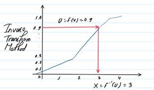

Inverse function

**Remark:** If you’d like to generate a nice, beautiful $Exp(\lambda)$ pdf on a computer then

1. Generate 10000 $Unif(0,1)$. Use rand function in excel or unifrnd in Matlab).
2. Plug those 10000 into equation for X above and
3. Plot the histogram of X.

**Another way to find pdf of a function of a continuous RV**

Suppose that $Y=h(x)$ is a monotonic function of a continuous RV X having pdf $f(x)$ and cdf $F(x)$. Let’s get the pdf $g(y)$ of $Y$ directly.

$$\begin{aligned}
g(y) &= \frac{d}{dy}G(y) \\
&= \frac{d}{dy}P(Y \le y) \\
&= \frac{d}{dy}P(X \le h^{-1}(y)) \;\;\; (\text{h(x) is monotonic})
\\
&= \frac{d}{dy}F(h^{-1}(y)) \\
&= f(h^{-1}(y)) \big{|}\frac{dh^{-1}(y)}{dy}\big{|} \;\;\;
(\text{chain rule})
\end{aligned}$$
**Example:** Suppose that $f(x)=3x^2$, $0<x<1$. Let $Y = h(x) = x^{1/2}$ which is monotone increasing.
$$\begin{aligned}
g(y) &= &= f(h^{-1}(y)) \big{|}\frac{dh^{-1}(y)}{dy}\big{|} \\
&= f(y^2) \big{|}\frac{d(y^2)}{dy} \big{|} \\
&= 3y^42y \\
&= 6y^5, \;\;\; 0<y<1
\end{aligned}$$

Explanation

$$Y = X^{1/2}$$
$$X = Y^2$$
$$h^{-1}(y) = X = Y^2 \;\;\; h^{-1}(y) \text{is inverse function of h(x)
expressed in terms of y}$$
$$f(h^{-1}(y)) = f(y^2) = 3y^4$$

Theorem (why LOTUS works): Let us assume h(.) is monotonically increasing. Then
$$\begin{aligned}
E[h(x)] &= E[Y] \\
&= \int_R yf(h^{-1}(y)) \big{|}\frac{dh^{-1}(y)}{dy} \big{|}dy \\
&= \int_R h(x)f(x) \big{|}\frac{dx}{dy} \big{|}dy \\
&= \int_R h(x)f(x)dx
\end{aligned}$$

# 4. Bivariate Random Variable

We will look at two random variables simultaneously.

**Example:** Choose a person at random. Look at their height and weight $(X,Y)$. Obviously, $X$ and $Y$ will be related somehow.

## 4.1 Joint Distribution

### 4.1.1 Discrete Random Variable

Definition: If $X$ and $Y$ are discrete random variables then $(X,Y)$ is called **jointly discrete bivariate random variable**.

The joint (or bivariate) pmf is
$$f(x,y) = P(X=x, Y=y), \;\; \forall x,y$$
**Properties**

- $0 \le f(x,y) \le 1$
- $\Sigma_x \Sigma_y f(x,y)=1$
- $A \subseteq \mathbb{R} \Longrightarrow P((X,Y) \in A) = \Sigma \Sigma_{(x,y)\in A} f(x,y)$

**Example:** 3 Socks in a box numbered 1,2,3. Draw 2 socks at random without replacement. X = number of the first sox, Y = number of the second sock. The joint pmf $f(x,y)$ is

$$\begin{array}{c|ccc|c}
f(x,y) & x=1 & x=2 & x=3 & P(Y=y) \\
\hline
y=1 & 0 & \frac{1}{6} & \frac{1}{6} & \frac{1}{3} \\
y=2 & \frac{1}{6} & 0 & \frac{1}{6} & \frac{1}{3} \\
y=3 & \frac{1}{6} & \frac{1}{6} & 0 & \frac{1}{3} \\
\hline
P(X=x) & \frac{1}{3} & \frac{1}{3} & \frac{1}{3} & 1
\end{array}$$

- Diagnol entries X=Y is 0 because you can’t pick same sock twice.
- Each non-diagnol entry has probability $\frac{1}{6}$ since there are $3!=6$ ways to select socks.

$f_x(x)=P(X=x)$ is the **marginal pmf of X**. $f_y(y) = P(Y=y)$ is the **marginal pmf of Y**.

**By the law of Total Probability**:
$$P(X=1) = \Sigma_{y=1}^{3}P(X=1, Y=1) =\frac{1}{3}$$
In addition;
$$\begin{aligned}
P(X>2, Y \ge 2)
&= \Sigma_{x \ge 2} \Sigma_{y \ge 2} f(x,y) \\
&= f(2,2)+f(2,3)+f(3,2)+f(3,3) \\
&= 0+\frac{1}{6}+\frac{1}{6}+0 \\
&= \frac{1}{3}
\end{aligned}$$

### 4.1.2 Continuous Random Variable

Definition: If $X$ and $Y$ are continuous random variables then $(X,Y)$ is a **jointly continuous bivariate random variable** if there exists a magic function $f(x,y)$ such that

- $f(x,y) \ge 0$, $Vx,y$
- $\int\int_{R^2}f(x,y)dxdy=1$
- $P(A)=P((X,Y) \in A) = \int\int_Af(x,y)dxdy$

In this case, $f(x,y)$ is called the **joint pdf**. If $A \subseteq \mathbb{R}^2$ then $P(A)$ is the volume between $f(x,y)$ and $A$. Think of $f(x,y)dxdy \approx P(x < X < x+dx, y<Y<y+dy)$

**Example:** Choose a point $(X,Y)$ at random in the interior of the circle inscribed in the unit square $C = (x-\frac{1}{2})^2+(y-\frac{1}{2})^2 \le \frac{1}{4}$. Find the pdf $(X,Y)$.

Area of circle is
$$\pi (\frac{1}{2})^2 = \frac{\pi}{4}$$
$$f(x,y) =
\begin{cases}
\frac{4}{\pi} & \text{if } (x,y) \in C \\
0 & \text{if otherwise} \\
\end{cases}$$
$f(x,y) = \frac{4}{\pi}$ because if you integrate $\frac{4}{\pi}$ in the region of circle you get 1.

**Application:** Toss n darts randomly into the unit square. The probability that any individual dart will land in the circle is $\frac{\pi}{4}$. It stands to reason that the proportion of darts $\hat{P}_n$ that land in the circle will be approximately $\frac{\pi}{4}$. So you can use $4\hat{P}_n$ to estimate $\pi$.

**Example:** Suppose that
$$f(x,y) =
\begin{cases}
4xy & \text{if } 0 \le x \le 1, 0 \le y \le 1 \\
0 & \text{otherwise}
\end{cases}$$
Find the probability (volume) of the region $0 \le y \le 1-x^2$.
$$\begin{aligned}
V &= \int_0^1\int_0^{1-x^2}4xydydx \\
&= \int_0^1\int_0^{\sqrt{1-y}}4xydxdy \\
&= \frac{1}{3}
\end{aligned}$$

## 4.2 Cumulative Distribution Function

Definition: The **joint (bivariate cdf)** of $X$ and $Y$ is
$$F(X,Y) = P(X \le x, Y \le y) \text{ for all } x,y$$
$$F(X,Y) =
\begin{cases}
\Sigma\Sigma_{s \le x, t \le y}f(s,t) & \text{ discrete} \\
\int_{-\infty}^{y}\int_{-\int}^{x}f(s,t)dsdt & \text { continuous}
\end{cases}$$
Going from CDF’s to PDF’s (continuous case): 1-dimension: $f(x) = F'(x) = \frac{d}{dx}\int_{-\infty}^{x}f(t)dt$

2-dimension; $f(x,y) = \frac{\partial^2}{\partial{x}\partial{y}}F(x,y) = \frac{\partial^2}{\partial{x}\partial{y}}\int_{-\infty}^{x} \int_{-\infty}^{y}f(s,t)dtds$

**Properties:**

- $F(X,Y)$ is non-decreasing in both $x$ and $y$.
- $\lim_{x \rightarrow -\infty}F(x,y) = \lim_{y \rightarrow -\infty} F(x,y) = 0$
- $\lim_{x \rightarrow -\infty}F(x,y) = F_Y(y) = P(Y \le y) \;\; \text{ marginal CDF of Y}$
- $\lim_{y \rightarrow -\infty}F(x,y) = F_X(x) = P(X \le x) \;\; \text{ marginal CDF of X}$
- $lim_{x \rightarrow -\infty}lim_{y \rightarrow -\infty}F(x,y) = 1$
- $F(x,y)$ is continuous from the right in both $x$ and $y$.

**Example:** Suppose
$$F(x,y) =
\begin{cases}
1-e^{--x}-e^{-y}+e^{-(x+y)} & \text{if } x \ge 0, y \ge 0 \\
0 & \text{if } x<0 \text{ or } y<0
\end{cases}$$
The marginal CDF of X is
$$F_X(x) = lim_{y \rightarrow \infty}F(x,y) =
\begin{cases}
1-e^{-x} & \text{if } x \ge 0 \\
0 & \text{ if } x<0
\end{cases}$$
The Joint PDF is
$$\begin{aligned}
f(x,y) &= \frac{\partial^2}{\partial{x}\partial{y}}F(x,y) \\
&= \frac{\partial}{\partial{y}}(e^{-x}-e^{-y}e^{-x}) \\
&= e^{-(x+y)} \;\; \text{ if } \;\; x \ge 0, y \ge 0
\end{aligned}$$
Marginal distribution from Joint,
$$f_X(x) = \int_{0}^{\infty}f(x,y)dy$$

## 4.3 Marginal Distribution

By Total Probability,

Definition: If $X$ and $Y$ are **jointly continuous**, then the **marginal PDF’s** of $X$ and $Y$ are
$$\begin{aligned}
f_X(x) = \int_{\mathbb{R}}f(x,y)dy \\
f_Y(y)=\int_{\mathbb{R}}f(x,y)dx
\end{aligned}$$
**Example:**
$$f(x,y) =
\begin{cases}
e^{-(x+y)} & \text{ if } x \ge 0, y \ge 0 \\
o & \text{ otherwise }
\end{cases}$$
Then marginal PDF of $X$ is
$$f_X(x) = \int_{\mathbb{R}}f(x,y)dy = \int_0^{\infty}e^{-(x+y)}dy =e^{-x}
\text{ if } x \ge 0$$
**Example:**
$$f(x,y) =
\begin{cases}
\frac{21}{4}x^2y & \text{ if } x^2 \le y \le 1 \\
0 & \text{ otherwise }
\end{cases}$$
Note **funny limits** where PDF is positive i.e., $x^2 \le y \le 1$.
$$\begin{aligned}
f_X(x) &= \int_{\mathbb{R}}f(x,y)dy \\
&= \int_{\mathbb{R}}^1 \frac{21}{4}x^2ydy \\
&= \frac{21}{8}x^2(1-x^4), -1 \le x \le 1
\end{aligned}$$
If we integrate $\frac{21}{8}x^2(1-x^4)$ from $-1$ to $1$, it must integrate to $1$ because we know legitimate PDF $f(x)$ must integrate to $1$.

## 4.4 Conditional Distributions

Recall the conditional probability,
$$P(A|B) = \frac{P(A \cap B)}{P(B)} \text{ if } P(B) > 0$$
Suppose that $X$ and $Y$ are jointly discrete RVs. Then if $P(X=x)>0$.
$$P(Y=y|X=x) = \frac{P(X=x \cap Y=y)}{P(X=x)} = \frac{f(x,y)}{f_X(x)}$$